# Practicum 2

## Load Data

### Parse XML Document

```r
fn <- "pubmed_sample.xml"

# Reading XML file and parse into DOM
xmlDOM <- xmlParse(file = fn, encoding="UTF-8")

# gGt root node
r <- xmlRoot(xmlDOM)

# Get number of articles in XML file
numArticles <- xmlSize(r)
```

### Parse Article Information

```r
# Looping through all of the articles
for ( i in 1:numArticles ){

  # parse first article
  article <- r[[i]]

  # ------------------- #
  # Journal Information #
  # ------------------- #

  a.journal <- parseJournalInfo(article)

  # Check to see if journal already exists in journal.df
  journalID <- rowExists(a.journal, journal.df)

  # If journal doesn't exist, add it to the data frame
  if ( journalID == 0 ){

    # Set journalID to be the next unused row num in journal.df
    journalID <- nrow(journal.df) + 1

    # add record to data frame
    journal.df[journalID,2:ncol(journal.df)] <- a.journal
    journal.df[journalID, 1] <- journalID
  }

  # ------------- #
  # Journal Issue #
  # ------------- #

  an.issue <- parseJournalIssueInfo(journalID, article)

  issueID <- rowExists(an.issue, journal_issue.df)

  # If journal issue doesn't exist, add it to the data frame
  if ( issueID == 0 ){

    # Set issue_id to be the next unused row num in journal_issue.df
    issueID <- nrow(journal_issue.df) + 1

    # add record to data frame
    journal_issue.df[issueID,2:ncol(journal_issue.df)] <- an.issue
    journal_issue.df[issueID, 1] <- issueID
  }

  # -------- #
  # Articles #
  # -------- #

  an.article <- parseArticleInfo(issueID, article)

  articleID <- rowExists(an.article, article.df)

  # If journal issue doesn't exist, add it to the data frame
  if ( articleID == 0 ){

    # Set issue_id to be the next unused row num in journal_issue.df
    articleID <- nrow(article.df) + 1

    # add record to data frame
    article.df[articleID,2:ncol(article.df)] <- an.article
    article.df[articleID, 1] <- articleID
  }

  # ------- #
  # Authors #
  # ------- #

  authorsQuery <- "./MedlineCitation/Article/AuthorList/Author"
  authorsResultSet <- xpathSApply(article, authorsQuery)

  # Loop through the AuthorsSet, extracting info and adding to authors table
  for ( j in 1:xmlSize(authorsResultSet) ){

    author <- authorsResultSet[[j]]
    last_name <- str_to_title(xmlValue(author[[1]]))
    fore_name <- str_to_title(xmlValue(author[[2]]))
    initials <- toupper(xmlValue(author[[3]]))

    an.author <- data.frame(last_name, fore_name, initials,
                          stringsAsFactors = FALSE)

    authorID <- rowExists(an.author, author.df)

    # If author doesn't exist, add it to the data frame
    if ( authorID == 0 ){

      # Set authorID to be the next unused row num in author.df
      authorID <- nrow(author.df) + 1

      # add record to data frame
      author.df[authorID,2:ncol(author.df)] <- an.author
      author.df[authorID, 1] <- authorID
    }

    # Retrieve next line in the junction table and add linking to author and article
    articleAuthorID <- nrow(article_author_junction.df) + 1
    an.article_author_junction <- data.frame(articleAuthorID, authorID, articleID)
    article_author_junction.df[articleAuthorID,] <- an.article_author_junction
  }

  # -------- #
  # Abstract #
  # -------- #

  abstractInfoQuery <- "./MedlineCitation/Article/Abstract/AbstractText"
  abstractInfoDataSet <- xpathSApply(article, abstractInfoQuery)

  # iterate through list of abstract info, create an abstract record and add it
  # to the abstract.df
  for ( j in 1:length(abstractInfoDataSet) ){
    abstractRecord <- abstractInfoDataSet[j]
    label <- xmlAttrs(abstractRecord[[1]])[1]
    nlm <- xmlAttrs(abstractRecord[[1]])[2]
    text <- xmlValue(abstractRecord[[1]])

    # if any of the data is not found, set it to UNKNOWN
    if ( is.null(label) ) label <- "UNKNOWN"
    if ( is.null(nlm) ) nlm <- "UNKNOWN"
    if ( is.null(text) ) text <- "UNKNOWN"

    abstractID <- nrow(abstract.df) + 1

    an.abstractEntry <- data.frame(abstractID, articleID, nlm, label, text )

    abstract.df[abstractID,] <- an.abstractEntry
  }

  # ------- #
  # History #
  # ------- #

  historyDataQuery <- "./PubmedData/History/PubMedPubDate"
  historyDataSet <- xpathSApply(article, historyDataQuery)

  for ( j in 1:length(historyDataSet) ){
    historyEntry <- historyDataSet[j]
    publicationStatus <- xmlAttrs(historyEntry[[1]])
    year <- xmlValue(historyEntry[[1]][[1]])
    month <- xmlValue(historyEntry[[1]][[2]])
    day <- xmlValue(historyEntry[[1]][[3]])

    historyEntryID <- nrow(history.df) + 1

    # add to df
    a.historyEntry <- data.frame(historyEntryID, articleID, publicationStatus,
                                 year, month, day)
    history.df[historyEntryID,] <- a.historyEntry
  }
}
```

## Upload Data

```r
dbWriteTable(dbcon, "Author", author.df, row.names = FALSE, append = TRUE)
```

```
## [1] TRUE
```

```r
dbWriteTable(dbcon, "Article", article.df, row.names = FALSE, append = TRUE)
```

```
## [1] TRUE
```

```r
dbWriteTable(dbcon, "Abstract", abstract.df, row.names = FALSE, append = TRUE)
```

```
## [1] TRUE
```

```r
dbWriteTable(dbcon, "Article_Author_Junction", article_author_junction.df, row.names = FALSE, append = TRUE)
```

```
## [1] TRUE
```

```r
dbWriteTable(dbcon, "History", history.df, row.names = FALSE, append = TRUE)
```

```
## [1] TRUE
```

```r
dbWriteTable(dbcon, "Journal", journal.df, row.names = FALSE, append = TRUE)
```

```
## [1] TRUE
```

```r
dbWriteTable(dbcon, "Journal_Issue", journal_issue.df, row.names = FALSE, append = TRUE)
```

```
## [1] TRUE
```

# Part 2 - Create Star/Snowflake Schema

## ERD

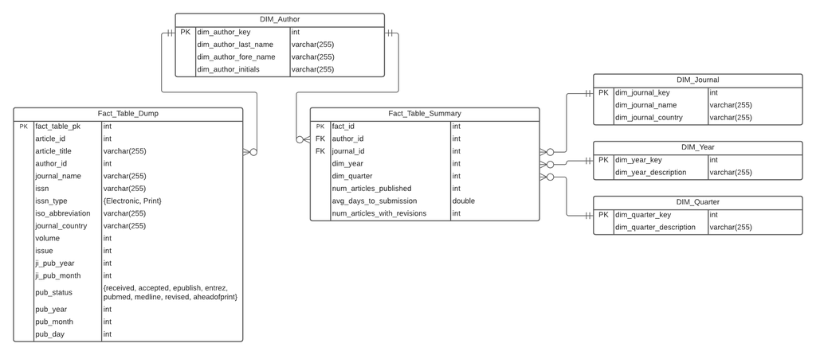

## Data Frames for the Dimensions

### Year Dimension

```r
# Create the data frames
dim_year.df <- data.frame(dim_year_key = integer(),
                          dim_year_description = character(),
                          stringsAsFactors = FALSE)

# Extract all possible years from the publication information
publication_years <- dbGetQuery(dbcon, "SELECT DISTINCT publication_year
                                        AS year
                                        FROM Journal_Issue")
publication_years <- publication_years[,1]

# Define the ALL
dim_year.df[1,] <- data.frame(0, "ALL")

# Load the data frame
for ( i in 1:length(publication_years) ) {
  row_number <- nrow(dim_year.df) + 1
  dim_year.df[row_number,] <- data.frame(i, publication_years[i])
}
```

### Quarter Dimension

```r
# Create the data frame
dim_quarter.df <- data.frame(dim_quarter_key = integer(),
                             dim_quarter_description = character(),
                             stringsAsFactors = FALSE)

# Define all possible quarters
quarters_list = c("ALL", "Q1", "Q2", "Q3", "Q4")

# Load the data frame
for ( i in 1:length(quarters_list) ){
  dim_quarter.df[i,] <- data.frame(i-1, quarters_list[i])
}
```

### Author Dimension

```r
# Create the data frame
dim_author.df <- data.frame(dim_author_key = integer(),
                            dim_author_last_name = character(),
                            dim_author_fore_name = character(),
                            dim_author_initials = character(),
                            stringsAsFactors = FALSE)

# Define the ALL
dim_author.df[1,] <- data.frame(0, "ALL", "ALL", "ALL")

# Load the data frame
author_info_from_db <- dbGetQuery(dbcon, "SELECT Author.aut_id AS dim_author_key,
                                          Author.author_last_name AS dim_author_last_name,
                                          Author.author_fore_name AS dim_author_fore_name,
                                          Author.author_initials AS dim_author_initials
                                          FROM Author")

dim_author.df <- rbind(dim_author.df, author_info_from_db)
```

### Journal Dimension

```r
# Create the data frame
dim_journal.df <- data.frame(dim_journal_key = integer(),
                             dim_journal_name = integer(),
                             dim_journal_country = integer(),
                             stringsAsFactors = FALSE)

# Define the ALL
dim_journal.df[1,] <- data.frame(0, "ALL", "ALL")

# Load the data frame
journal_info_from_db <- dbGetQuery(dbcon, "SELECT j_id AS dim_journal_key,
                                           journal_name AS dim_journal_name,
                                           journal_country AS dim_journal_country
                                           FROM Journal;")

dim_journal.df <- rbind(dim_journal.df, journal_info_from_db)
```

## Create Table for Dimensions

### DIM_Year

```sql
DROP TABLE IF EXISTS DIM_Year;
```

```sql
CREATE TABLE DIM_Year (
  dim_year_key INT PRIMARY KEY,
  dim_year_description VARCHAR(255) NOT NULL,

  INDEX (dim_year_key),
  INDEX (dim_year_description)
);
```

```sql
SELECT * FROM DIM_Year;
```

0 records

| dim_year_key | dim_year_description |
| --- | --- |

### DIM_Quarter

```sql
DROP TABLE IF EXISTS DIM_Quarter;
```

```sql
CREATE TABLE DIM_Quarter (
  dim_quarter_key INT PRIMARY KEY,
  dim_quarter_description VARCHAR(255) NOT NULL,

  INDEX (dim_quarter_key),
  INDEX (dim_quarter_description)
);
```

```sql
SELECT * FROM DIM_Quarter;
```

0 records

| dim_quarter_key | dim_quarter_description |
| --- | --- |

### DIM_Author

```sql
DROP TABLE IF EXISTS DIM_Author;
```

```sql
CREATE TABLE DIM_Author (
  dim_author_key INT PRIMARY KEY,
  dim_author_last_name VARCHAR(255) NOT NULL,
  dim_author_fore_name VARCHAR(255) NOT NULL,
  dim_author_initials VARCHAR(255) NOT NULL,

  INDEX (dim_author_key),
  INDEX (dim_author_last_name),
  INDEX (dim_author_fore_name),
  INDEX (dim_author_initials)
);
```

```sql
SELECT * FROM DIM_Author;
```

0 records

| dim_author_key | dim_author_last_name | dim_author_fore_name | dim_author_initials |
| --- | --- | --- | --- |

### DIM_Journal

```sql
DROP TABLE IF EXISTS DIM_Journal;
```

```sql
CREATE TABLE DIM_Journal (
  dim_journal_key INT PRIMARY KEY,
  dim_journal_name VARCHAR(255) NOT NULL,
  dim_journal_country VARCHAR(255) NOT NULL,

  INDEX (dim_journal_key),
  INDEX (dim_journal_name),
  INDEX (dim_journal_country)
);
```

```sql
SELECT * FROM DIM_Journal;
```

0 records

| dim_journal_key | dim_journal_name | dim_journal_country |
| --- | --- | --- |

### Uploading DIM Data

```r
# we can run this when you think the table is OK
dbWriteTable(dbcon, "DIM_Year", dim_year.df, row.names = FALSE, append = TRUE)
```

```
## [1] TRUE
```

```r
dbWriteTable(dbcon, "DIM_Quarter", dim_quarter.df, row.names = FALSE, append = TRUE)
```

```
## [1] TRUE
```

```r
dbWriteTable(dbcon, "DIM_Author", dim_author.df, row.names = FALSE, append = TRUE)
```

```
## [1] TRUE
```

```r
dbWriteTable(dbcon, "DIM_Journal", dim_journal.df, row.names = FALSE, append = TRUE)
```

```
## [1] TRUE
```

## Fact_Table_Dump Data Frame (Part 2 Question 1)

### Create table for Fact_Table_Dump

```sql
DROP TABLE IF EXISTS Fact_Table_Dump;
```

```sql
CREATE TABLE Fact_Table_Dump (
  fact_table_pk INT PRIMARY KEY,
  article_id INT NOT NULL,
  article_title VARCHAR(250) NOT NULL,
  author_id INT NOT NULL,
  journal_name VARCHAR(250) NOT NULL,
  issn INT NOT NULL,
  issn_type VARCHAR(250) NOT NULL,
  iso_abbreviation VARCHAR(250) NOT NULL,
  journal_country VARCHAR(250) NOT NULL,
  volume INT NOT NULL,
  issue INT NOT NULL,
  ji_pub_year INT NOT NULL,
  ji_pub_month INT NOT NULL,
  pub_status VARCHAR(250) NOT NULL,
  pub_year INT NOT NULL,
  pub_month INT NOT NULL,
  pub_day INT NOT NULL,

  CONSTRAINT author_dim_id_fk_dump FOREIGN KEY (author_id) REFERENCES DIM_Author(dim_author_key)
);
```

### Create data frame to upload Fact_Table_Dump

```r
factTableDump.df <- dbGetQuery(dbcon, 'SELECT ROW_NUMBER() OVER (ORDER BY ART.article_title ASC) AS fact_table_pk
                                , ART.art_id as article_id
                                , ART.article_title
                                , AJ.author_id
                                , J.journal_name
                                , J.issn
                                , J.issn_type
                                , J.iso_abbreviation
                                , J.journal_country
                                , JI.volume
                                , JI.issue
                                , JI.publication_year as ji_pub_year
                                , JI.publication_month as ji_pub_month
                                , H.pub_status
                                , H.year as pub_year
                                , H.month as pub_month
                                , H.day as pub_day
                                FROM Journal AS J
                                JOIN Journal_Issue AS JI
                                ON JI.journal_id = J.j_id
                                JOIN Article AS ART
                                ON ART.journal_issue_id = JI.issue_id
                                JOIN Article_Author_Junction AS AJ
                                ON ART.art_id = AJ.article_id
                                JOIN History AS H
                                ON H.article_id = ART.art_id;')

head(factTableDump.df)
```

```
##   fact_table_pk article_id
## 1             1         13
## 2             2         13
## 3             3         13
## 4             4         13
## 5             5         13
## 6             6         13
##                                                                                                                               article_title
## 1 Beyond repeated-measures analysis of variance: advanced statistical methods for the analysis of longitudinal data in anesthesia research.
## 2 Beyond repeated-measures analysis of variance: advanced statistical methods for the analysis of longitudinal data in anesthesia research.
## 3 Beyond repeated-measures analysis of variance: advanced statistical methods for the analysis of longitudinal data in anesthesia research.
## 4 Beyond repeated-measures analysis of variance: advanced statistical methods for the analysis of longitudinal data in anesthesia research.
## 5 Beyond repeated-measures analysis of variance: advanced statistical methods for the analysis of longitudinal data in anesthesia research.
## 6 Beyond repeated-measures analysis of variance: advanced statistical methods for the analysis of longitudinal data in anesthesia research.
##   author_id                          journal_name      issn  issn_type
```

[output cut: 20 more lines]

### Upload Data for Fact Table Dump

```r
dbWriteTable(dbcon, "Fact_Table_Dump", factTableDump.df, row.names = FALSE, append = TRUE)
```

```
## [1] TRUE
```

```sql
SELECT * FROM Fact_Table_Dump;
```

Displaying records 1 - 10

| fact_table_pk | article_id | article_title | author_id | journal_name | issn | issn_type | iso_abbreviation | journal_country | volume | issue | ji_pub_year | ji_pub_month | pub_status | pub_year | pub_month | pub_day |
| --- | --- | --- | --- | --- | --- | --- | --- | --- | --- | --- | --- | --- | --- | --- | --- | --- |
| 1 | 13 | Beyond repeated-measures analysis of variance: advanced statistical methods for the analysis of longitudinal data in anesthesia research. | 32 | Regional Anesthesia And Pain Medicine | 1532 | Electronic | Reg Anesth Pain Med | United States | 37 | 1 | 2012 | 1 | entrez | 2011 | 12 | 23 |
| 2 | 13 | Beyond repeated-measures analysis of variance: advanced statistical methods for the analysis of longitudinal data in anesthesia research. | 3 | Regional Anesthesia And Pain Medicine | 1532 | Electronic | Reg Anesth Pain Med | United States | 37 | 1 | 2012 | 1 | entrez | 2011 | 12 | 23 |
| 3 | 13 | Beyond repeated-measures analysis of variance: advanced statistical methods for the analysis of longitudinal data in anesthesia research. | 4 | Regional Anesthesia And Pain Medicine | 1532 | Electronic | Reg Anesth Pain Med | United States | 37 | 1 | 2012 | 1 | entrez | 2011 | 12 | 23 |
| 4 | 13 | Beyond repeated-measures analysis of variance: advanced statistical methods for the analysis of longitudinal data in anesthesia research. | 32 | Regional Anesthesia And Pain Medicine | 1532 | Electronic | Reg Anesth Pain Med | United States | 37 | 1 | 2012 | 1 | pubmed | 2011 | 12 | 23 |
| 5 | 13 | Beyond repeated-measures analysis of variance: advanced statistical methods for the analysis of longitudinal data in anesthesia research. | 3 | Regional Anesthesia And Pain Medicine | 1532 | Electronic | Reg Anesth Pain Med | United States | 37 | 1 | 2012 | 1 | pubmed | 2011 | 12 | 23 |
| 6 | 13 | Beyond repeated-measures analysis of variance: advanced statistical methods for the analysis of longitudinal data in anesthesia research. | 4 | Regional Anesthesia And Pain Medicine | 1532 | Electronic | Reg Anesth Pain Med | United States | 37 | 1 | 2012 | 1 | pubmed | 2011 | 12 | 23 |
| 7 | 13 | Beyond repeated-measures analysis of variance: advanced statistical methods for the analysis of longitudinal data in anesthesia research. | 32 | Regional Anesthesia And Pain Medicine | 1532 | Electronic | Reg Anesth Pain Med | United States | 37 | 1 | 2012 | 1 | medline | 2012 | 7 | 31 |
| 8 | 13 | Beyond repeated-measures analysis of variance: advanced statistical methods for the analysis of longitudinal data in anesthesia research. | 3 | Regional Anesthesia And Pain Medicine | 1532 | Electronic | Reg Anesth Pain Med | United States | 37 | 1 | 2012 | 1 | medline | 2012 | 7 | 31 |
| 9 | 13 | Beyond repeated-measures analysis of variance: advanced statistical methods for the analysis of longitudinal data in anesthesia research. | 4 | Regional Anesthesia And Pain Medicine | 1532 | Electronic | Reg Anesth Pain Med | United States | 37 | 1 | 2012 | 1 | medline | 2012 | 7 | 31 |
| 10 | 3 | Cerebrovascular reserve and stroke risk in patients with carotid stenosis or occlusion: a systematic review and meta-analysis. | 10 | Stroke; A Journal Of Cerebral Circulation | 1524 | Electronic | Stroke | United States | 43 | 11 | 2012 | 11 | entrez | 2012 | 10 | 24 |

## Summary_Fact_Table Data Frame (Part 2 Question 2)

```sql
DROP TABLE IF EXISTS Summary_Fact_Table;
```

```sql
CREATE TABLE Summary_Fact_Table (
  fact_id INT PRIMARY KEY AUTO_INCREMENT,
  journal_id INT NOT NULL,
  author_id INT NOT NULL,
  dim_year INT NOT NULL,
  dim_quarter INT NOT NULL,
  num_articles_published INT NOT NULL,
  avg_days_to_submission INT NOT NULL,
  num_articles_with_revisions INT NOT NULL,

  CONSTRAINT journal_dim_id_fk FOREIGN KEY (journal_id) REFERENCES DIM_Journal(dim_journal_key),
  CONSTRAINT author_dim_id_fk FOREIGN KEY (author_id) REFERENCES DIM_Author(dim_author_key),
  CONSTRAINT year_dim_id_fk FOREIGN KEY (dim_year) REFERENCES DIM_Year(dim_year_key),
  CONSTRAINT qurter_dim_id_fk FOREIGN KEY (dim_quarter) REFERENCES DIM_Quarter(dim_quarter_key),

  INDEX (journal_id),
  INDEX (author_id),
  INDEX (dim_year),
  INDEX (dim_quarter),
  INDEX (num_articles_published),
  INDEX (avg_days_to_submission),
  INDEX (num_articles_with_revisions)
);
```

```sql
SELECT * FROM Summary_Fact_Table;
```

0 records

| fact_id | journal_id | author_id | dim_year | dim_quarter | num_articles_published | avg_days_to_submission | num_articles_with_revisions |
| --- | --- | --- | --- | --- | --- | --- | --- |

## Functions to summarize the data

### getPublicationDate

Function to return publication date of an article as a date object

```r
# Function to return publication date of an article as a date object
getPublicationDate <- function(article_id) {

  # Defining the sql statement
  sqlStatement <- paste0('SELECT CONCAT(JI.publication_year,"-"
                        , JI.publication_month,"-","01")
                        AS PublicationDate
                        FROM Article
                        JOIN Journal_Issue AS JI
                        ON Article.journal_issue_id = JI.issue_id
                        WHERE art_id =', article_id)

  date <- dbGetQuery(dbcon, sqlStatement)

  # Looking for edge cases and defining them as NA
  if ( nrow(date) == 0 ) return(NA)

  return(as.Date(as.character(date), "%Y-%m-%d"))
}
```

### getHistoryDate

Function to retrieve date of history event of an article.

```r
# Function to retrieve date of history event of an article
getHistoryDate <- function(article_id, history_event) {

  # Defining the sql statement
  sqlStatement <- paste0('SELECT CONCAT(History.year, "-"
                        , History.month, "-", History.day)
                        AS DateReceived
                        FROM Article
                        JOIN History
                        ON Article.art_id = History.article_id
                        WHERE pub_status ="', history_event, '"
                        AND art_id = ', article_id)

  date <- dbGetQuery(dbcon, sqlStatement)

  # Looking for edge cases and defining them as NA
  if ( nrow(date) == 0 ) return(NA)

  return(as.Date(as.character(date), "%Y-%m-%d"))
}
```

### daysToPub

Function to get the number of days to publish for an article.

```r
# Function to get the number of days to publish for an article
daysToPub <- function(article_id) {

  # Defining the variables
  received_date <- getHistoryDate(article_id, "received")
  pub_date <- getPublicationDate(article_id)

  # Looking for edge cases
  if ( is.na(received_date) ){
    difference <- 0

  # Otherwise calculating the difference between dates
  } else{
    difference <- difftime(pub_date, received_date, units = "days")
  }

  return(as.numeric(difference))
}
```

### numArticlesPublishedByJournal

Function to find num of articles published by journal.

```r
# Function to find num of articles published by journal
numArticlesPublishedByJournal <- function(journal_id, year, quarter) {

  if ( year == "ALL" & quarter == "ALL" ){
    sqlStatement <- paste0('SELECT COUNT(ART.art_id)
                            FROM Journal AS J
                            JOIN Journal_Issue AS JI
                            ON JI.journal_id = J.j_id
                            JOIN Article AS ART
                            ON ART.journal_issue_id = JI.issue_id
                            WHERE J.j_id = ', journal_id);

  } else if ( year == "ALL" & quarter == "Q1") {
    sqlStatement <- paste0('SELECT COUNT(ART.art_id)
                            FROM Journal AS J
                            JOIN Journal_Issue AS JI
                            ON JI.journal_id = J.j_id
                            JOIN Article AS ART
                            ON ART.journal_issue_id = JI.issue_id
                            WHERE J.j_id =', journal_id,
                            ' AND (JI.publication_month >= 1
                            AND JI.publication_month <= 3)');
  } else if ( year == "ALL" & quarter == "Q2") {
    sqlStatement <- paste0('SELECT COUNT(ART.art_id)
                            FROM Journal AS J
                            JOIN Journal_Issue AS JI
                            ON JI.journal_id = J.j_id
                            JOIN Article AS ART
                            ON ART.journal_issue_id = JI.issue_id
                            WHERE J.j_id =', journal_id,
                            ' AND (JI.publication_month >= 4
                            AND JI.publication_month <= 6)');

  } else if ( year == "ALL" & quarter == "Q3") {
    sqlStatement <- paste0('SELECT COUNT(ART.art_id)
                            FROM Journal AS J
                            JOIN Journal_Issue AS JI
                            ON JI.journal_id = J.j_id
                            JOIN Article AS ART
                            ON ART.journal_issue_id = JI.issue_id
                            WHERE J.j_id =', journal_id,
                            ' AND (JI.publication_month >= 7
                            AND JI.publication_month <= 9)');

  } else if ( year == "ALL" & quarter == "Q4") {
    sqlStatement <- paste0('SELECT COUNT(ART.art_id)
                            FROM Journal AS J
                            JOIN Journal_Issue AS JI
                            ON JI.journal_id = J.j_id
                            JOIN Article AS ART
                            ON ART.journal_issue_id = JI.issue_id
                            WHERE J.j_id =', journal_id,
                            ' AND (JI.publication_month >= 10
                            AND JI.publication_month <= 12)')
  } else if ( year > 0 & quarter == "ALL" ){
    sqlStatement <- paste0('SELECT COUNT(ART.art_id)
                            FROM Journal AS J
                            JOIN Journal_Issue AS JI
                            ON JI.journal_id = J.j_id
                            JOIN Article AS ART
                            ON ART.journal_issue_id = JI.issue_id
                            WHERE J.j_id = ', journal_id,
                            ' AND JI.publication_year = ', year);

  } else if ( year > 0 & quarter == "Q1") {
    sqlStatement <- paste0('SELECT COUNT(ART.art_id)
                            FROM Journal AS J
                            JOIN Journal_Issue AS JI
                            ON JI.journal_id = J.j_id
                            JOIN Article AS ART
                            ON ART.journal_issue_id = JI.issue_id
                            WHERE J.j_id =', journal_id,
                            ' AND JI.publication_year = ', year,
                            ' AND (JI.publication_month >= 1
                           AND JI.publication_month <= 3)');
  } else if ( year > 0 & quarter == "Q2") {
    sqlStatement <- paste0('SELECT COUNT(ART.art_id)
                            FROM Journal AS J
                            JOIN Journal_Issue AS JI
                            ON JI.journal_id = J.j_id
                            JOIN Article AS ART
                            ON ART.journal_issue_id = JI.issue_id
                            WHERE J.j_id =', journal_id,
                            ' AND JI.publication_year = ', year,
                            ' AND (JI.publication_month >= 4
                           AND JI.publication_month <= 6)');

  } else if ( year > 0 & quarter == "Q3") {
    sqlStatement <- paste0('SELECT COUNT(ART.art_id)
                            FROM Journal AS J
                            JOIN Journal_Issue AS JI
                            ON JI.journal_id = J.j_id
                            JOIN Article AS ART
                            ON ART.journal_issue_id = JI.issue_id
                            WHERE J.j_id =', journal_id,
                            ' AND JI.publication_year = ', year,
                            ' AND (JI.publication_month >= 7
                           AND JI.publication_month <= 9)');

  } else if ( year > 0 & quarter == "Q4") {
    sqlStatement <- paste0('SELECT COUNT(ART.art_id)
                            FROM Journal AS J
                            JOIN Journal_Issue AS JI
                            ON JI.journal_id = J.j_id
                            JOIN Article AS ART
                            ON ART.journal_issue_id = JI.issue_id
                            WHERE J.j_id =', journal_id,
                            ' AND JI.publication_year = ', year,
                            ' AND (JI.publication_month >= 10
                           AND JI.publication_month <= 12)');
  }

  count <- dbGetQuery(dbcon, sqlStatement)[1]
  return(as.numeric(count))
}
```

### numArticlesRevisedByJournal

Function to get num of articles with revisions based on journal.

```r
# Function to get num of articles with revisions based on journal
numArticlesRevisedByJournal <- function(journal_id, year, quarter) {

  if ( year == "ALL" & quarter == "ALL" ){
    sqlStatement <- paste0('SELECT COUNT(ART.art_id)
                            FROM Journal AS J
                            JOIN Journal_Issue AS JI
                            ON JI.journal_id = J.j_id
                            JOIN Article AS ART
                            ON ART.journal_issue_id = JI.issue_id
                            JOIN History AS H
                            ON ART.art_id = H.article_id
                            WHERE J.j_id = ', journal_id,
                            ' AND H.pub_status = "revised"');

  } else if ( year == "ALL" & quarter == "Q1") {
    sqlStatement <- paste0('SELECT COUNT(ART.art_id)
                            FROM Journal AS J
                            JOIN Journal_Issue AS JI
                            ON JI.journal_id = J.j_id
                            JOIN Article AS ART
                            ON ART.journal_issue_id = JI.issue_id
                            JOIN History AS H
                            ON ART.art_id = H.article_id
                            WHERE J.j_id = ', journal_id,
                            ' AND H.pub_status = "revised"
                            AND (JI.publication_month >= 1
                            AND JI.publication_month <= 3)');

  } else if ( year == "ALL" & quarter == "Q2") {
    sqlStatement <- paste0('SELECT COUNT(ART.art_id)
                            FROM Journal AS J
                            JOIN Journal_Issue AS JI
                            ON JI.journal_id = J.j_id
                            JOIN Article AS ART
                            ON ART.journal_issue_id = JI.issue_id
                            JOIN History AS H
                            ON ART.art_id = H.article_id
                            WHERE J.j_id = ', journal_id,
                            ' AND H.pub_status = "revised"
                            AND (JI.publication_month >= 4
                            AND JI.publication_month <= 6)');

  } else if ( year == "ALL" & quarter == "Q3") {
    sqlStatement <- paste0('SELECT COUNT(ART.art_id)
                            FROM Journal AS J
                            JOIN Journal_Issue AS JI
                            ON JI.journal_id = J.j_id
                            JOIN Article AS ART
                            ON ART.journal_issue_id = JI.issue_id
                            JOIN History AS H
                            ON ART.art_id = H.article_id
                            WHERE J.j_id = ', journal_id,
                            ' AND H.pub_status = "revised"
                            AND (JI.publication_month >= 7
                            AND JI.publication_month <= 9)');

  } else if ( year == "ALL" & quarter == "Q4") {
    sqlStatement <- paste0('SELECT COUNT(ART.art_id)
                            FROM Journal AS J
                            JOIN Journal_Issue AS JI
                            ON JI.journal_id = J.j_id
                            JOIN Article AS ART
                            ON ART.journal_issue_id = JI.issue_id
                            JOIN History AS H
                            ON ART.art_id = H.article_id
                            WHERE J.j_id = ', journal_id,
                            ' AND H.pub_status = "revised"
                            AND (JI.publication_month >= 10
                            AND JI.publication_month <= 12)');
  } else if ( year > 0 & quarter == "ALL" ){
    sqlStatement <- paste0('SELECT COUNT(ART.art_id)
                            FROM Journal AS J
                            JOIN Journal_Issue AS JI
                            ON JI.journal_id = J.j_id
                            JOIN Article AS ART
                            ON ART.journal_issue_id = JI.issue_id
                            JOIN History AS H
                            ON ART.art_id = H.article_id
                            WHERE J.j_id = ', journal_id,
                            ' AND JI.publication_year = ', year,
                            ' AND H.pub_status = "revised"');

  } else if ( year > 0 & quarter == "Q1") {
    sqlStatement <- paste0('SELECT COUNT(ART.art_id)
                            FROM Journal AS J
                            JOIN Journal_Issue AS JI
                            ON JI.journal_id = J.j_id
                            JOIN Article AS ART
                            ON ART.journal_issue_id = JI.issue_id
                            JOIN History AS H
                            ON ART.art_id = H.article_id
                            WHERE J.j_id = ', journal_id,
                            ' AND JI.publication_year = ', year,
                            ' AND H.pub_status = "revised"
                           AND (JI.publication_month >= 1
                           AND JI.publication_month <= 3)');

  } else if ( year > 0 & quarter == "Q2") {
    sqlStatement <- paste0('SELECT COUNT(ART.art_id)
                            FROM Journal AS J
                            JOIN Journal_Issue AS JI
                            ON JI.journal_id = J.j_id
                            JOIN Article AS ART
                            ON ART.journal_issue_id = JI.issue_id
                            JOIN History AS H
                            ON ART.art_id = H.article_id
                            WHERE J.j_id = ', journal_id,
                            ' AND JI.publication_year = ', year,
                            ' AND H.pub_status = "revised"
                           AND (JI.publication_month >= 4
                           AND JI.publication_month <= 6)');

  } else if ( year > 0 & quarter == "Q3") {
    sqlStatement <- paste0('SELECT COUNT(ART.art_id)
                            FROM Journal AS J
                            JOIN Journal_Issue AS JI
                            ON JI.journal_id = J.j_id
                            JOIN Article AS ART
                            ON ART.journal_issue_id = JI.issue_id
                            JOIN History AS H
                            ON ART.art_id = H.article_id
                            WHERE J.j_id = ', journal_id,
                            ' AND JI.publication_year = ', year,
                            ' AND H.pub_status = "revised"
                           AND (JI.publication_month >= 7
                           AND JI.publication_month <= 9)');

  } else if ( year > 0 & quarter == "Q4") {
    sqlStatement <- paste0('SELECT COUNT(ART.art_id)
                            FROM Journal AS J
                            JOIN Journal_Issue AS JI
                            ON JI.journal_id = J.j_id
                            JOIN Article AS ART
                            ON ART.journal_issue_id = JI.issue_id
                            JOIN History AS H
                            ON ART.art_id = H.article_id
                            WHERE J.j_id = ', journal_id,
                            ' AND JI.publication_year = ', year,
                            ' AND H.pub_status = "revised"
                           AND (JI.publication_month >= 10
                           AND JI.publication_month <= 12)');
  }

  count <- dbGetQuery(dbcon, sqlStatement)
  return(as.numeric(count))
}
```

### numArticlesPublishedByAuthor

Function to find num of articles published by author.

```r
# Function to find num of articles published by author
numArticlesPublishedByAuthor <- function(author_id, year, quarter) {

  if ( year == "ALL" & quarter == "ALL" ){
    sqlStatement <- paste0('SELECT COUNT(ART.art_id)
                            FROM Author AS A
                            JOIN Article_Author_Junction AS AJ
                            ON A.aut_id = AJ.author_id
                            JOIN Article AS ART
                            ON AJ.article_id = ART.art_id
                            JOIN Journal_Issue AS JI
                            ON ART.journal_issue_id = JI.issue_id
                            WHERE A.aut_id = ', author_id);

  } else if ( year == "ALL" & quarter == "Q1") {
    sqlStatement <- paste0('SELECT COUNT(ART.art_id)
                            FROM Author AS A
                            JOIN Article_Author_Junction AS AJ
                            ON A.aut_id = AJ.author_id
                            JOIN Article AS ART
                            ON AJ.article_id = ART.art_id
                            JOIN Journal_Issue AS JI
                            ON ART.journal_issue_id = JI.issue_id
                            WHERE A.aut_id = ', author_id,
                            ' AND (JI.publication_month >= 1
                            AND JI.publication_month <= 3)');
  } else if ( year == "ALL" & quarter == "Q2") {
    sqlStatement <- paste0('SELECT COUNT(ART.art_id)
                            FROM Author AS A
                            JOIN Article_Author_Junction AS AJ
                            ON A.aut_id = AJ.author_id
                            JOIN Article AS ART
                            ON AJ.article_id = ART.art_id
                            JOIN Journal_Issue AS JI
                            ON ART.journal_issue_id = JI.issue_id
                            WHERE A.aut_id = ', author_id,
                            ' AND (JI.publication_month >= 4
                            AND JI.publication_month <= 6)');

  } else if ( year == "ALL" & quarter == "Q3") {
    sqlStatement <- paste0('SELECT COUNT(ART.art_id)
                            FROM Author AS A
                            JOIN Article_Author_Junction AS AJ
                            ON A.aut_id = AJ.author_id
                            JOIN Article AS ART
                            ON AJ.article_id = ART.art_id
                            JOIN Journal_Issue AS JI
                            ON ART.journal_issue_id = JI.issue_id
                            WHERE A.aut_id = ', author_id,
                            ' AND (JI.publication_month >= 7
                            AND JI.publication_month <= 9)');

  } else if ( year == "ALL" & quarter == "Q4") {
    sqlStatement <- paste0('SELECT COUNT(ART.art_id)
                            FROM Author AS A
                            JOIN Article_Author_Junction AS AJ
                            ON A.aut_id = AJ.author_id
                            JOIN Article AS ART
                            ON AJ.article_id = ART.art_id
                            JOIN Journal_Issue AS JI
                            ON ART.journal_issue_id = JI.issue_id
                            WHERE A.aut_id = ', author_id,
                            ' AND (JI.publication_month >= 10
                             AND JI.publication_month <= 12)');
  } else if ( year > 0 & quarter == "ALL" ){
    sqlStatement <- paste0('SELECT COUNT(ART.art_id)
                            FROM Author AS A
                            JOIN Article_Author_Junction AS AJ
                            ON A.aut_id = AJ.author_id
                            JOIN Article AS ART
                            ON AJ.article_id = ART.art_id
                            JOIN Journal_Issue AS JI
                            ON ART.journal_issue_id = JI.issue_id
                            WHERE A.aut_id = ', author_id,
                           ' AND JI.publication_year = ', year);

  } else if ( year > 0 & quarter == "Q1") {
    sqlStatement <- paste0('SELECT COUNT(ART.art_id)
                            FROM Author AS A
                            JOIN Article_Author_Junction AS AJ
                            ON A.aut_id = AJ.author_id
                            JOIN Article AS ART
                            ON AJ.article_id = ART.art_id
                            JOIN Journal_Issue AS JI
                            ON ART.journal_issue_id = JI.issue_id
                            WHERE A.aut_id = ', author_id,
                            ' AND JI.publication_year = ', year,
                            ' AND (JI.publication_month >= 1
                            AND JI.publication_month <= 3)');
  } else if ( year > 0 & quarter == "Q2") {
    sqlStatement <- paste0('SELECT COUNT(ART.art_id)
                            FROM Author AS A
                            JOIN Article_Author_Junction AS AJ
                            ON A.aut_id = AJ.author_id
                            JOIN Article AS ART
                            ON AJ.article_id = ART.art_id
                            JOIN Journal_Issue AS JI
                            ON ART.journal_issue_id = JI.issue_id
                            WHERE A.aut_id = ', author_id,
                            ' AND JI.publication_year = ', year,
                            ' AND (JI.publication_month >= 4
                            AND JI.publication_month <= 6)');

  } else if ( year > 0 & quarter == "Q3") {
    sqlStatement <- paste0('SELECT COUNT(ART.art_id)
                            FROM Author AS A
                            JOIN Article_Author_Junction AS AJ
                            ON A.aut_id = AJ.author_id
                            JOIN Article AS ART
                            ON AJ.article_id = ART.art_id
                            JOIN Journal_Issue AS JI
                            ON ART.journal_issue_id = JI.issue_id
                            WHERE A.aut_id = ', author_id,
                            ' AND JI.publication_year = ', year,
                            ' AND (JI.publication_month >= 7
                            AND JI.publication_month <= 9)');

  } else if ( year > 0 & quarter == "Q4") {
    sqlStatement <- paste0('SELECT COUNT(ART.art_id)
                            FROM Author AS A
                            JOIN Article_Author_Junction AS AJ
                            ON A.aut_id = AJ.author_id
                            JOIN Article AS ART
                            ON AJ.article_id = ART.art_id
                            JOIN Journal_Issue AS JI
                            ON ART.journal_issue_id = JI.issue_id
                            WHERE A.aut_id = ', author_id,
                            ' AND JI.publication_year = ', year,
                            ' AND (JI.publication_month >= 10
                             AND JI.publication_month <= 12)');
  }

  count <- dbGetQuery(dbcon, sqlStatement)[1]
  return(as.numeric(count))
}
```

### numArticlesRevisedByAuthor

Function to get num of articles with revisions based on author.

```r
# Function to get num of articles with revisions based on author
numArticlesRevisedByAuthor <- function(author_id, year, quarter) {
  if ( year == "ALL" & quarter == "ALL" ){
    sqlStatement <- paste0('SELECT COUNT(ART.art_id)
                            FROM Author AS A
                            JOIN Article_Author_Junction AS AJ
                            ON A.aut_id = AJ.author_id
                            JOIN Article AS ART
                            ON AJ.article_id = ART.art_id
                            JOIN Journal_Issue AS JI
                            ON ART.journal_issue_id = JI.issue_id
                            JOIN History AS H
                            ON ART.art_id = H.article_id
                            WHERE A.aut_id = ', author_id,
                            ' AND H.pub_status = "revised"');

  } else if ( year == "ALL" & quarter == "Q1") {
    sqlStatement <- paste0('SELECT COUNT(ART.art_id)
                            FROM Author AS A
                            JOIN Article_Author_Junction AS AJ
                            ON A.aut_id = AJ.author_id
                            JOIN Article AS ART
                            ON AJ.article_id = ART.art_id
                            JOIN Journal_Issue AS JI
                            ON ART.journal_issue_id = JI.issue_id
                            JOIN History AS H
                            ON ART.art_id = H.article_id
                            WHERE A.aut_id = ', author_id,
                            ' AND H.pub_status = "revised"
                            AND (JI.publication_month >= 1
                            AND JI.publication_month <= 3)');

  } else if ( year == "ALL" & quarter == "Q2") {
    sqlStatement <- paste0('SELECT COUNT(ART.art_id)
                            FROM Author AS A
                            JOIN Article_Author_Junction AS AJ
                            ON A.aut_id = AJ.author_id
                            JOIN Article AS ART
                            ON AJ.article_id = ART.art_id
                            JOIN Journal_Issue AS JI
                            ON ART.journal_issue_id = JI.issue_id
                            JOIN History AS H
                            ON ART.art_id = H.article_id
                            WHERE A.aut_id = ', author_id,
                            ' AND H.pub_status = "revised"
                            AND (JI.publication_month >= 4
                            AND JI.publication_month <= 6)');

  } else if ( year == "ALL" & quarter == "Q3") {
    sqlStatement <- paste0('SELECT COUNT(ART.art_id)
                            FROM Author AS A
                            JOIN Article_Author_Junction AS AJ
                            ON A.aut_id = AJ.author_id
                            JOIN Article AS ART
                            ON AJ.article_id = ART.art_id
                            JOIN Journal_Issue AS JI
                            ON ART.journal_issue_id = JI.issue_id
                            JOIN History AS H
                            ON ART.art_id = H.article_id
                            WHERE A.aut_id = ', author_id,
                            ' AND H.pub_status = "revised"
                            AND (JI.publication_month >= 7
                            AND JI.publication_month <= 9)');

  } else if ( year == "ALL" & quarter == "Q4") {
    sqlStatement <- paste0('SELECT COUNT(ART.art_id)
                            FROM Author AS A
                            JOIN Article_Author_Junction AS AJ
                            ON A.aut_id = AJ.author_id
                            JOIN Article AS ART
                            ON AJ.article_id = ART.art_id
                            JOIN Journal_Issue AS JI
                            ON ART.journal_issue_id = JI.issue_id
                            JOIN History AS H
                            ON ART.art_id = H.article_id
                            WHERE A.aut_id = ', author_id,
                            ' AND H.pub_status = "revised"
                            AND (JI.publication_month >= 10
                            AND JI.publication_month <= 12)');
  } else if ( year > 0 & quarter == "ALL" ){
    sqlStatement <- paste0('SELECT COUNT(ART.art_id)
                            FROM Author AS A
                            JOIN Article_Author_Junction AS AJ
                            ON A.aut_id = AJ.author_id
                            JOIN Article AS ART
                            ON AJ.article_id = ART.art_id
                            JOIN Journal_Issue AS JI
                            ON ART.journal_issue_id = JI.issue_id
                            JOIN History AS H
                            ON ART.art_id = H.article_id
                            WHERE A.aut_id = ', author_id,
                            ' AND JI.publication_year = ', year,
                            ' AND H.pub_status = "revised"');

  } else if ( year > 0 & quarter == "Q1") {
    sqlStatement <- paste0('SELECT COUNT(ART.art_id)
                            FROM Author AS A
                            JOIN Article_Author_Junction AS AJ
                            ON A.aut_id = AJ.author_id
                            JOIN Article AS ART
                            ON AJ.article_id = ART.art_id
                            JOIN Journal_Issue AS JI
                            ON ART.journal_issue_id = JI.issue_id
                            JOIN History AS H
                            ON ART.art_id = H.article_id
                            WHERE A.aut_id = ', author_id,
                            ' AND JI.publication_year = ', year,
                            ' AND H.pub_status = "revised"
                            AND (JI.publication_month >= 1
                            AND JI.publication_month <= 3)');

  } else if ( year > 0 & quarter == "Q2") {
    sqlStatement <- paste0('SELECT COUNT(ART.art_id)
                            FROM Author AS A
                            JOIN Article_Author_Junction AS AJ
                            ON A.aut_id = AJ.author_id
                            JOIN Article AS ART
                            ON AJ.article_id = ART.art_id
                            JOIN Journal_Issue AS JI
                            ON ART.journal_issue_id = JI.issue_id
                            JOIN History AS H
                            ON ART.art_id = H.article_id
                            WHERE A.aut_id = ', author_id,
                            ' AND JI.publication_year = ', year,
                            ' AND H.pub_status = "revised"
                            AND (JI.publication_month >= 4
                            AND JI.publication_month <= 6)');

  } else if ( year > 0 & quarter == "Q3") {
    sqlStatement <- paste0('SELECT COUNT(ART.art_id)
                            FROM Author AS A
                            JOIN Article_Author_Junction AS AJ
                            ON A.aut_id = AJ.author_id
                            JOIN Article AS ART
                            ON AJ.article_id = ART.art_id
                            JOIN Journal_Issue AS JI
                            ON ART.journal_issue_id = JI.issue_id
                            JOIN History AS H
                            ON ART.art_id = H.article_id
                            WHERE A.aut_id = ', author_id,
                            ' AND JI.publication_year = ', year,
                            ' AND H.pub_status = "revised"
                            AND (JI.publication_month >= 7
                            AND JI.publication_month <= 9)');

  } else if ( year > 0 & quarter == "Q4") {
    sqlStatement <- paste0('SELECT COUNT(ART.art_id)
                            FROM Author AS A
                            JOIN Article_Author_Junction AS AJ
                            ON A.aut_id = AJ.author_id
                            JOIN Article AS ART
                            ON AJ.article_id = ART.art_id
                            JOIN Journal_Issue AS JI
                            ON ART.journal_issue_id = JI.issue_id
                            JOIN History AS H
                            ON ART.art_id = H.article_id
                            WHERE A.aut_id = ', author_id,
                            ' AND JI.publication_year = ', year,
                            ' AND H.pub_status = "revised"
                            AND (JI.publication_month >= 10
                            AND JI.publication_month <= 12)');
  }

  count <- dbGetQuery(dbcon, sqlStatement)
  return(as.numeric(count))
}
```

### articleIDsPublishedByJournal

Function to return a list of article IDs associated with each journal

```r
# Function to find the article IDs associated with each journal
articleIDsPublishedByJournal <- function(journal_id, year, quarter) {

  # if quarter information isn't provided, pull just based on year
  if ( year == "ALL" & quarter == "ALL" ){
    sqlStatement <- paste0('SELECT ART.art_id
                            FROM Journal AS J
                            JOIN Journal_Issue AS JI
                            ON JI.journal_id = J.j_id
                            JOIN Article AS ART
                            ON ART.journal_issue_id = JI.issue_id
                            WHERE J.j_id = ', journal_id);

  } else if ( year == "ALL" & quarter == "Q1") {
    sqlStatement <- paste0('SELECT ART.art_id
                            FROM Journal AS J
                            JOIN Journal_Issue AS JI
                            ON JI.journal_id = J.j_id
                            JOIN Article AS ART
                            ON ART.journal_issue_id = JI.issue_id
                            WHERE J.j_id = ', journal_id,
                            ' AND (JI.publication_month >= 1
                            AND JI.publication_month <= 3)');

  } else if ( year == "ALL" & quarter == "Q2") {
    sqlStatement <- paste0('SELECT ART.art_id
                            FROM Journal AS J
                            JOIN Journal_Issue AS JI
                            ON JI.journal_id = J.j_id
                            JOIN Article AS ART
                            ON ART.journal_issue_id = JI.issue_id
                            WHERE J.j_id = ', journal_id,
                            ' AND (JI.publication_month >= 4
                            AND JI.publication_month <= 6)');

  } else if ( year == "ALL" & quarter == "Q3") {
    sqlStatement <- paste0('SELECT ART.art_id
                            FROM Journal AS J
                            JOIN Journal_Issue AS JI
                            ON JI.journal_id = J.j_id
                            JOIN Article AS ART
                            ON ART.journal_issue_id = JI.issue_id
                            WHERE J.j_id = ', journal_id,
                            ' AND (JI.publication_month >= 7
                            AND JI.publication_month <= 9)');

  } else if ( year == "ALL" & quarter == "Q4") {
    sqlStatement <- paste0('SELECT ART.art_id
                            FROM Journal AS J
                            JOIN Journal_Issue AS JI
                            ON JI.journal_id = J.j_id
                            JOIN Article AS ART
                            ON ART.journal_issue_id = JI.issue_id
                            WHERE J.j_id = ', journal_id,
                            ' AND (JI.publication_month >= 10
                            AND JI.publication_month <= 12)');
  } else if ( year > 0 & quarter == "ALL" ){
    sqlStatement <- paste0('SELECT ART.art_id
                            FROM Journal AS J
                            JOIN Journal_Issue AS JI
                            ON JI.journal_id = J.j_id
                            JOIN Article AS ART
                            ON ART.journal_issue_id = JI.issue_id
                            WHERE J.j_id = ', journal_id,
                           ' AND JI.publication_year = ', year);

  } else if ( year > 0 & quarter == "Q1") {
    sqlStatement <- paste0('SELECT ART.art_id
                            FROM Journal AS J
                            JOIN Journal_Issue AS JI
                            ON JI.journal_id = J.j_id
                            JOIN Article AS ART
                            ON ART.journal_issue_id = JI.issue_id
                            WHERE J.j_id = ', journal_id,
                            ' AND JI.publication_year = ', year,
                            ' AND (JI.publication_month >= 1
                           AND JI.publication_month <= 3)');

  } else if ( year > 0 & quarter == "Q2") {
    sqlStatement <- paste0('SELECT ART.art_id
                            FROM Journal AS J
                            JOIN Journal_Issue AS JI
                            ON JI.journal_id = J.j_id
                            JOIN Article AS ART
                            ON ART.journal_issue_id = JI.issue_id
                            WHERE J.j_id = ', journal_id,
                            ' AND JI.publication_year = ', year,
                            ' AND (JI.publication_month >= 4
                           AND JI.publication_month <= 6)');

  } else if ( year > 0 & quarter == "Q3") {
    sqlStatement <- paste0('SELECT ART.art_id
                            FROM Journal AS J
                            JOIN Journal_Issue AS JI
                            ON JI.journal_id = J.j_id
                            JOIN Article AS ART
                            ON ART.journal_issue_id = JI.issue_id
                            WHERE J.j_id = ', journal_id,
                            ' AND JI.publication_year = ', year,
                            ' AND (JI.publication_month >= 7
                           AND JI.publication_month <= 9)');

  } else if ( year > 0 & quarter == "Q4") {
    sqlStatement <- paste0('SELECT ART.art_id
                            FROM Journal AS J
                            JOIN Journal_Issue AS JI
                            ON JI.journal_id = J.j_id
                            JOIN Article AS ART
                            ON ART.journal_issue_id = JI.issue_id
                            WHERE J.j_id = ', journal_id,
                            ' AND JI.publication_year = ', year,
                            ' AND (JI.publication_month >= 10
                           AND JI.publication_month <= 12)');
  }

  article_list <- dbGetQuery(dbcon, sqlStatement)[[1]]
  if ( length(article_list) == 0 ) return(NA)
  return(article_list)
}
```

### articleIDsPublishedByAuthor

Function to return a list of article IDs associated with each author.

```r
# Function to find the article IDs associated with each author
articleIDsPublishedByAuthor <- function(author_id, year, quarter) {

  if ( year == "ALL" & quarter == "ALL" ){
    sqlStatement <- paste0('SELECT ART.art_id
                            FROM Author AS A
                            JOIN Article_Author_Junction AS AJ
                            ON A.aut_id = AJ.author_id
                            JOIN Article AS ART
                            ON AJ.article_id = ART.art_id
                            JOIN Journal_Issue AS JI
                            ON ART.journal_issue_id = JI.issue_id
                            WHERE A.aut_id = ', author_id);

  } else if ( year == "ALL" & quarter == "Q1") {
    sqlStatement <- paste0('SELECT ART.art_id
                            FROM Author AS A
                            JOIN Article_Author_Junction AS AJ
                            ON A.aut_id = AJ.author_id
                            JOIN Article AS ART
                            ON AJ.article_id = ART.art_id
                            JOIN Journal_Issue AS JI
                            ON ART.journal_issue_id = JI.issue_id
                            WHERE A.aut_id = ', author_id,
                            ' AND (JI.publication_month >= 1
                            AND JI.publication_month <= 3)');
  } else if ( year == "ALL" & quarter == "Q2") {
    sqlStatement <- paste0('SELECT ART.art_id
                            FROM Author AS A
                            JOIN Article_Author_Junction AS AJ
                            ON A.aut_id = AJ.author_id
                            JOIN Article AS ART
                            ON AJ.article_id = ART.art_id
                            JOIN Journal_Issue AS JI
                            ON ART.journal_issue_id = JI.issue_id
                            WHERE A.aut_id = ', author_id,
                            ' AND (JI.publication_month >= 4
                            AND JI.publication_month <= 6)');

  } else if ( year == "ALL" & quarter == "Q3") {
    sqlStatement <- paste0('SELECT ART.art_id
                            FROM Author AS A
                            JOIN Article_Author_Junction AS AJ
                            ON A.aut_id = AJ.author_id
                            JOIN Article AS ART
                            ON AJ.article_id = ART.art_id
                            JOIN Journal_Issue AS JI
                            ON ART.journal_issue_id = JI.issue_id
                            WHERE A.aut_id = ', author_id,
                            ' AND (JI.publication_month >= 7
                            AND JI.publication_month <= 9)');

  } else if ( year == "ALL" & quarter == "Q4") {
    sqlStatement <- paste0('SELECT ART.art_id
                            FROM Author AS A
                            JOIN Article_Author_Junction AS AJ
                            ON A.aut_id = AJ.author_id
                            JOIN Article AS ART
                            ON AJ.article_id = ART.art_id
                            JOIN Journal_Issue AS JI
                            ON ART.journal_issue_id = JI.issue_id
                            WHERE A.aut_id = ', author_id,
                            ' AND (JI.publication_month >= 10
                             AND JI.publication_month <= 12)');
  } else if ( year > 0 & quarter == "ALL" ){
    sqlStatement <- paste0('SELECT ART.art_id
                            FROM Author AS A
                            JOIN Article_Author_Junction AS AJ
                            ON A.aut_id = AJ.author_id
                            JOIN Article AS ART
                            ON AJ.article_id = ART.art_id
                            JOIN Journal_Issue AS JI
                            ON ART.journal_issue_id = JI.issue_id
                            WHERE A.aut_id = ', author_id,
                           ' AND JI.publication_year = ', year);

  } else if ( year > 0 & quarter == "Q1") {
    sqlStatement <- paste0('SELECT ART.art_id
                            FROM Author AS A
                            JOIN Article_Author_Junction AS AJ
                            ON A.aut_id = AJ.author_id
                            JOIN Article AS ART
                            ON AJ.article_id = ART.art_id
                            JOIN Journal_Issue AS JI
                            ON ART.journal_issue_id = JI.issue_id
                            WHERE A.aut_id = ', author_id,
                            ' AND JI.publication_year = ', year,
                            ' AND (JI.publication_month >= 1
                            AND JI.publication_month <= 3)');
  } else if ( year > 0 & quarter == "Q2") {
    sqlStatement <- paste0('SELECT ART.art_id
                            FROM Author AS A
                            JOIN Article_Author_Junction AS AJ
                            ON A.aut_id = AJ.author_id
                            JOIN Article AS ART
                            ON AJ.article_id = ART.art_id
                            JOIN Journal_Issue AS JI
                            ON ART.journal_issue_id = JI.issue_id
                            WHERE A.aut_id = ', author_id,
                            ' AND JI.publication_year = ', year,
                            ' AND (JI.publication_month >= 4
                            AND JI.publication_month <= 6)');

  } else if ( year > 0 & quarter == "Q3") {
    sqlStatement <- paste0('SELECT ART.art_id
                            FROM Author AS A
                            JOIN Article_Author_Junction AS AJ
                            ON A.aut_id = AJ.author_id
                            JOIN Article AS ART
                            ON AJ.article_id = ART.art_id
                            JOIN Journal_Issue AS JI
                            ON ART.journal_issue_id = JI.issue_id
                            WHERE A.aut_id = ', author_id,
                            ' AND JI.publication_year = ', year,
                            ' AND (JI.publication_month >= 7
                            AND JI.publication_month <= 9)');

  } else if ( year > 0 & quarter == "Q4") {
    sqlStatement <- paste0('SELECT ART.art_id
                            FROM Author AS A
                            JOIN Article_Author_Junction AS AJ
                            ON A.aut_id = AJ.author_id
                            JOIN Article AS ART
                            ON AJ.article_id = ART.art_id
                            JOIN Journal_Issue AS JI
                            ON ART.journal_issue_id = JI.issue_id
                            WHERE A.aut_id = ', author_id,
                            ' AND JI.publication_year = ', year,
                            ' AND (JI.publication_month >= 10
                             AND JI.publication_month <= 12)');
  }

  article_list <- dbGetQuery(dbcon, sqlStatement)[[1]]
  if ( length(article_list) == 0 ) return(NA)
  return(article_list)
}
```

### numArticlesPublishedByYearQuarter

```r
# Function to find num of articles published by journal
numArticlesPublishedByYearQuarter <- function(year, quarter) {

  if ( year == "ALL" & quarter == "ALL" ){
    sqlStatement <- paste0('SELECT COUNT(ART.art_id)
                            FROM Article AS ART');

  } else if ( year == "ALL" & quarter == "Q1") {
    sqlStatement <- paste0('SELECT COUNT(ART.art_id)
                            FROM Journal AS J
                            JOIN Journal_Issue AS JI
                            ON JI.journal_id = J.j_id
                            JOIN Article AS ART
                            ON ART.journal_issue_id = JI.issue_id
                            WHERE (JI.publication_month >= 1
                            AND JI.publication_month <= 3)');
  } else if ( year == "ALL" & quarter == "Q2") {
    sqlStatement <- paste0('SELECT COUNT(ART.art_id)
                            FROM Journal AS J
                            JOIN Journal_Issue AS JI
                            ON JI.journal_id = J.j_id
                            JOIN Article AS ART
                            ON ART.journal_issue_id = JI.issue_id
                            WHERE (JI.publication_month >= 4
                            AND JI.publication_month <= 6)');

  } else if ( year == "ALL" & quarter == "Q3") {
    sqlStatement <- paste0('SELECT COUNT(ART.art_id)
                            FROM Journal AS J
                            JOIN Journal_Issue AS JI
                            ON JI.journal_id = J.j_id
                            JOIN Article AS ART
                            ON ART.journal_issue_id = JI.issue_id
                            WHERE (JI.publication_month >= 7
                            AND JI.publication_month <= 9)');

  } else if ( year == "ALL" & quarter == "Q4") {
    sqlStatement <- paste0('SELECT COUNT(ART.art_id)
                            FROM Journal AS J
                            JOIN Journal_Issue AS JI
                            ON JI.journal_id = J.j_id
                            JOIN Article AS ART
                            ON ART.journal_issue_id = JI.issue_id
                            WHERE (JI.publication_month >= 10
                            AND JI.publication_month <= 12)')
  } else if ( year > 0 & quarter == "ALL" ){
    sqlStatement <- paste0('SELECT COUNT(ART.art_id)
                            FROM Journal AS J
                            JOIN Journal_Issue AS JI
                            ON JI.journal_id = J.j_id
                            JOIN Article AS ART
                            ON ART.journal_issue_id = JI.issue_id
                            WHERE JI.publication_year = ', year);

  } else if ( year > 0 & quarter == "Q1") {
    sqlStatement <- paste0('SELECT COUNT(ART.art_id)
                            FROM Journal AS J
                            JOIN Journal_Issue AS JI
                            ON JI.journal_id = J.j_id
                            JOIN Article AS ART
                            ON ART.journal_issue_id = JI.issue_id
                            WHERE JI.publication_year = ', year,
                            ' AND (JI.publication_month >= 1
                           AND JI.publication_month <= 3)');
  } else if ( year > 0 & quarter == "Q2") {
    sqlStatement <- paste0('SELECT COUNT(ART.art_id)
                            FROM Journal AS J
                            JOIN Journal_Issue AS JI
                            ON JI.journal_id = J.j_id
                            JOIN Article AS ART
                            ON ART.journal_issue_id = JI.issue_id
                            WHERE JI.publication_year = ', year,
                            ' AND (JI.publication_month >= 4
                           AND JI.publication_month <= 6)');

  } else if ( year > 0 & quarter == "Q3") {
    sqlStatement <- paste0('SELECT COUNT(ART.art_id)
                            FROM Journal AS J
                            JOIN Journal_Issue AS JI
                            ON JI.journal_id = J.j_id
                            JOIN Article AS ART
                            ON ART.journal_issue_id = JI.issue_id
                            WHERE JI.publication_year = ', year,
                            ' AND (JI.publication_month >= 7
                           AND JI.publication_month <= 9)');

  } else if ( year > 0 & quarter == "Q4") {
    sqlStatement <- paste0('SELECT COUNT(ART.art_id)
                            FROM Journal AS J
                            JOIN Journal_Issue AS JI
                            ON JI.journal_id = J.j_id
                            JOIN Article AS ART
                            ON ART.journal_issue_id = JI.issue_id
                            WHERE JI.publication_year = ', year,
                            ' AND (JI.publication_month >= 10
                           AND JI.publication_month <= 12)');
  }

  count <- dbGetQuery(dbcon, sqlStatement)[1]
  return(as.numeric(count))
}
```

### numArticlesRevisedByYearQuarter

```r
# Function to get num of articles with revisions based on journal
numArticlesRevisedByYearQuarter <- function(year, quarter) {

  if ( year == "ALL" & quarter == "ALL" ){
    sqlStatement <- paste0('SELECT COUNT(ART.art_id)
                            FROM Journal AS J
                            JOIN Journal_Issue AS JI
                            ON JI.journal_id = J.j_id
                            JOIN Article AS ART
                            ON ART.journal_issue_id = JI.issue_id
                            JOIN History AS H
                            ON ART.art_id = H.article_id
                            WHERE H.pub_status = "revised"');

  } else if ( year == "ALL" & quarter == "Q1") {
    sqlStatement <- paste0('SELECT COUNT(ART.art_id)
                            FROM Journal AS J
                            JOIN Journal_Issue AS JI
                            ON JI.journal_id = J.j_id
                            JOIN Article AS ART
                            ON ART.journal_issue_id = JI.issue_id
                            JOIN History AS H
                            ON ART.art_id = H.article_id
                            WHERE H.pub_status = "revised"
                            AND (JI.publication_month >= 1
                            AND JI.publication_month <= 3)');

  } else if ( year == "ALL" & quarter == "Q2") {
    sqlStatement <- paste0('SELECT COUNT(ART.art_id)
                            FROM Journal AS J
                            JOIN Journal_Issue AS JI
                            ON JI.journal_id = J.j_id
                            JOIN Article AS ART
                            ON ART.journal_issue_id = JI.issue_id
                            JOIN History AS H
                            ON ART.art_id = H.article_id
                            WHERE H.pub_status = "revised"
                            AND (JI.publication_month >= 4
                            AND JI.publication_month <= 6)');

  } else if ( year == "ALL" & quarter == "Q3") {
    sqlStatement <- paste0('SELECT COUNT(ART.art_id)
                            FROM Journal AS J
                            JOIN Journal_Issue AS JI
                            ON JI.journal_id = J.j_id
                            JOIN Article AS ART
                            ON ART.journal_issue_id = JI.issue_id
                            JOIN History AS H
                            ON ART.art_id = H.article_id
                            WHERE H.pub_status = "revised"
                            AND (JI.publication_month >= 7
                            AND JI.publication_month <= 9)');

  } else if ( year == "ALL" & quarter == "Q4") {
    sqlStatement <- paste0('SELECT COUNT(ART.art_id)
                            FROM Journal AS J
                            JOIN Journal_Issue AS JI
                            ON JI.journal_id = J.j_id
                            JOIN Article AS ART
                            ON ART.journal_issue_id = JI.issue_id
                            JOIN History AS H
                            ON ART.art_id = H.article_id
                            WHERE H.pub_status = "revised"
                            AND (JI.publication_month >= 10
                            AND JI.publication_month <= 12)');
  } else if ( year > 0 & quarter == "ALL" ){
    sqlStatement <- paste0('SELECT COUNT(ART.art_id)
                            FROM Journal AS J
                            JOIN Journal_Issue AS JI
                            ON JI.journal_id = J.j_id
                            JOIN Article AS ART
                            ON ART.journal_issue_id = JI.issue_id
                            JOIN History AS H
                            ON ART.art_id = H.article_id
                            WHERE JI.publication_year = ', year,
                            ' AND H.pub_status = "revised"');

  } else if ( year > 0 & quarter == "Q1") {
    sqlStatement <- paste0('SELECT COUNT(ART.art_id)
                            FROM Journal AS J
                            JOIN Journal_Issue AS JI
                            ON JI.journal_id = J.j_id
                            JOIN Article AS ART
                            ON ART.journal_issue_id = JI.issue_id
                            JOIN History AS H
                            ON ART.art_id = H.article_id
                            WHERE JI.publication_year = ', year,
                            ' AND H.pub_status = "revised"
                           AND (JI.publication_month >= 1
                           AND JI.publication_month <= 3)');

  } else if ( year > 0 & quarter == "Q2") {
    sqlStatement <- paste0('SELECT COUNT(ART.art_id)
                            FROM Journal AS J
                            JOIN Journal_Issue AS JI
                            ON JI.journal_id = J.j_id
                            JOIN Article AS ART
                            ON ART.journal_issue_id = JI.issue_id
                            JOIN History AS H
                            ON ART.art_id = H.article_id
                            WHERE JI.publication_year = ', year,
                            ' AND H.pub_status = "revised"
                           AND (JI.publication_month >= 4
                           AND JI.publication_month <= 6)');

  } else if ( year > 0 & quarter == "Q3") {
    sqlStatement <- paste0('SELECT COUNT(ART.art_id)
                            FROM Journal AS J
                            JOIN Journal_Issue AS JI
                            ON JI.journal_id = J.j_id
                            JOIN Article AS ART
                            ON ART.journal_issue_id = JI.issue_id
                            JOIN History AS H
                            ON ART.art_id = H.article_id
                            WHERE JI.publication_year = ', year,
                            ' AND H.pub_status = "revised"
                           AND (JI.publication_month >= 7
                           AND JI.publication_month <= 9)');

  } else if ( year > 0 & quarter == "Q4") {
    sqlStatement <- paste0('SELECT COUNT(ART.art_id)
                            FROM Journal AS J
                            JOIN Journal_Issue AS JI
                            ON JI.journal_id = J.j_id
                            JOIN Article AS ART
                            ON ART.journal_issue_id = JI.issue_id
                            JOIN History AS H
                            ON ART.art_id = H.article_id
                            WHERE JI.publication_year = ', year,
                            ' AND H.pub_status = "revised"
                           AND (JI.publication_month >= 10
                           AND JI.publication_month <= 12)');
  }

  count <- dbGetQuery(dbcon, sqlStatement)
  return(as.numeric(count))
}
```

### articleIDsPublishedByYearQuarter

```r
# Function to find the article IDs associated with each journal
articleIDsPublishedByYearQuarter <- function(year, quarter) {

  # if quarter information isn't provided, pull just based on year
  if ( year == "ALL" & quarter == "ALL" ){
    sqlStatement <- paste0('SELECT ART.art_id
                            FROM Article AS ART');

  } else if ( year == "ALL" & quarter == "Q1") {
    sqlStatement <- paste0('SELECT ART.art_id
                            FROM Journal AS J
                            JOIN Journal_Issue AS JI
                            ON JI.journal_id = J.j_id
                            JOIN Article AS ART
                            ON ART.journal_issue_id = JI.issue_id
                            WHERE (JI.publication_month >= 1
                            AND JI.publication_month <= 3)');

  } else if ( year == "ALL" & quarter == "Q2") {
    sqlStatement <- paste0('SELECT ART.art_id
                            FROM Journal AS J
                            JOIN Journal_Issue AS JI
                            ON JI.journal_id = J.j_id
                            JOIN Article AS ART
                            ON ART.journal_issue_id = JI.issue_id
                            WHERE (JI.publication_month >= 4
                            AND JI.publication_month <= 6)');

  } else if ( year == "ALL" & quarter == "Q3") {
    sqlStatement <- paste0('SELECT ART.art_id
                            FROM Journal AS J
                            JOIN Journal_Issue AS JI
                            ON JI.journal_id = J.j_id
                            JOIN Article AS ART
                            ON ART.journal_issue_id = JI.issue_id
                            WHERE (JI.publication_month >= 7
                            AND JI.publication_month <= 9)');

  } else if ( year == "ALL" & quarter == "Q4") {
    sqlStatement <- paste0('SELECT ART.art_id
                            FROM Journal AS J
                            JOIN Journal_Issue AS JI
                            ON JI.journal_id = J.j_id
                            JOIN Article AS ART
                            ON ART.journal_issue_id = JI.issue_id
                            WHERE (JI.publication_month >= 10
                            AND JI.publication_month <= 12)');
  } else if ( year > 0 & quarter == "ALL" ){
    sqlStatement <- paste0('SELECT ART.art_id
                            FROM Journal AS J
                            JOIN Journal_Issue AS JI
                            ON JI.journal_id = J.j_id
                            JOIN Article AS ART
                            ON ART.journal_issue_id = JI.issue_id
                            WHERE JI.publication_year = ', year);

  } else if ( year > 0 & quarter == "Q1") {
    sqlStatement <- paste0('SELECT ART.art_id
                            FROM Journal AS J
                            JOIN Journal_Issue AS JI
                            ON JI.journal_id = J.j_id
                            JOIN Article AS ART
                            ON ART.journal_issue_id = JI.issue_id
                            WHERE JI.publication_year = ', year,
                            ' AND (JI.publication_month >= 1
                           AND JI.publication_month <= 3)');

  } else if ( year > 0 & quarter == "Q2") {
    sqlStatement <- paste0('SELECT ART.art_id
                            FROM Journal AS J
                            JOIN Journal_Issue AS JI
                            ON JI.journal_id = J.j_id
                            JOIN Article AS ART
                            ON ART.journal_issue_id = JI.issue_id
                            WHERE JI.publication_year = ', year,
                            ' AND (JI.publication_month >= 4
                           AND JI.publication_month <= 6)');

  } else if ( year > 0 & quarter == "Q3") {
    sqlStatement <- paste0('SELECT ART.art_id
                            FROM Journal AS J
                            JOIN Journal_Issue AS JI
                            ON JI.journal_id = J.j_id
                            JOIN Article AS ART
                            ON ART.journal_issue_id = JI.issue_id
                            WHERE JI.publication_year = ', year,
                            ' AND (JI.publication_month >= 7
                           AND JI.publication_month <= 9)');

  } else if ( year > 0 & quarter == "Q4") {
    sqlStatement <- paste0('SELECT ART.art_id
                            FROM Journal AS J
                            JOIN Journal_Issue AS JI
                            ON JI.journal_id = J.j_id
                            JOIN Article AS ART
                            ON ART.journal_issue_id = JI.issue_id
                            WHERE JI.publication_year = ', year,
                            ' AND (JI.publication_month >= 10
                           AND JI.publication_month <= 12)');
  }

  article_list <- dbGetQuery(dbcon, sqlStatement)[[1]]
  if ( length(article_list) == 0 ) return(NA)
  return(article_list)
}
```

### avgDaysToPub

Function that takes in a list of article_ids and returns the average days to pub for that list of articles.

```r
# function that takes in a list of article_ids and returns the
# average days to pub for that list of articles
avgDaysToPub <- function(article_list) {

  if ( is.na(article_list[1]) ) return(0)

  total <- 0
  size <- length(article_list)

  if ( size == 1 ) {
    return (daysToPub(article_list[1]))
  } else {

    # else iterating over the list
    for ( i in size ) {
      day_result <- daysToPub(article_list[i])
      total <- total + day_result
    }

    return(total / size)
  }
}
```

## Populate the data for the summary table

```r
# Create the summary data frame
fact_table.df <- data.frame(fact_id = integer(),
                           journal_id = integer(),
                           author_id = integer(),
                           dim_year = integer(),
                           dim_quarter = integer(),
                           num_articles_published = integer(),
                           avg_days_to_submission = integer(),
                           num_articles_with_revisions = integer(),
                           stringsAsFactors = FALSE)

fact_table.df
```

```
## [1] fact_id                     journal_id
## [3] author_id                   dim_year
## [5] dim_quarter                 num_articles_published
## [7] avg_days_to_submission      num_articles_with_revisions
## <0 rows> (or 0-length row.names)
```

## Add in overall summary information

```r
  # loop through each quarter, incl the "ALL" quarter to get yearly totals
  for ( j in 1:nrow(dim_quarter.df) ) {

    # loop through each year
    for ( k in 1:nrow(dim_year.df) ) {

      # add in primary key
      pk <- nrow(fact_table.df) + 1

      # set up ids in fact table
      journal_id <- 0
      quarter <- dim_quarter.df[j,]$dim_quarter_key
      year <- dim_year.df[k,]$dim_year_key
      author_id <- 0

      year_description <- dim_year.df[k,]$dim_year_description
      quarter_description <- dim_quarter.df[j,]$dim_quarter_description

      # get number of articles published
      num_published <- numArticlesPublishedByYearQuarter(
        year_description, quarter_description)

      # retrieve the list of articles for analysis
      article_list <- articleIDsPublishedByYearQuarter(
        year_description, quarter_description)

      # get average days to publish
        days_to_pub <- avgDaysToPub(article_list)

      # get num revisions
      num_revisions <- numArticlesRevisedByYearQuarter(
        year_description, quarter_description)

      # put the data into the data frame
      fact_table.df[pk,] <- data.frame(
        pk, journal_id, author_id, year, quarter,
        num_published, days_to_pub, num_revisions,
        stringsAsFactors = FALSE)
    }
  }

head(fact_table.df)
```

```
##   fact_id journal_id author_id dim_year dim_quarter num_articles_published
## 1       1          0         0        0           0                     19
## 2       2          0         0        1           0                     16
## 3       3          0         0        2           0                      3
## 4       4          0         0        0           1                      8
## 5       5          0         0        1           1                      5
## 6       6          0         0        2           1                      3
##   avg_days_to_submission num_articles_with_revisions
## 1                 0.0000                           5
## 2                 0.0000                           3
## 3               107.6667                           2
## 4                 0.0000                           3
## 5                 0.0000                           1
## 6               107.6667                           2
```

## Summarize data of journals for fact table

```r
# loop through each journal, except the first "ALL"
for ( i in 2:nrow(dim_journal.df) ) {

  # loop through each quarter, incl the "ALL" quarter to get yearly totals
  for ( j in 1:nrow(dim_quarter.df) ) {

    # loop through each year
    for ( k in 1:nrow(dim_year.df) ) {

      # add in primary key
      pk <- nrow(fact_table.df) + 1

      # set up ids in fact table
      journal_id <- dim_journal.df[i,]$dim_journal_key
      quarter <- dim_quarter.df[j,]$dim_quarter_key
      year <- dim_year.df[k,]$dim_year_key
      author_id <- 0

      year_description <- dim_year.df[k,]$dim_year_description
      quarter_description <- dim_quarter.df[j,]$dim_quarter_description

      # get number of articles published
      num_published <- numArticlesPublishedByJournal(
        journal_id, year_description, quarter_description)

      # retrieve the list of articles for analysis
      article_list <- articleIDsPublishedByJournal(
        journal_id, year_description, quarter_description)

      # get average days to publish
        days_to_pub <- avgDaysToPub(article_list)

      # get num revisions
      num_revisions <- numArticlesRevisedByJournal(
        journal_id, year_description, quarter_description)

      # put the data into the data frame
      fact_table.df[pk,] <- data.frame(
        pk, journal_id, author_id, year, quarter,
        num_published, days_to_pub, num_revisions,
        stringsAsFactors = FALSE)
    }
  }
}
head(fact_table.df)
```

```
##   fact_id journal_id author_id dim_year dim_quarter num_articles_published
## 1       1          0         0        0           0                     19
## 2       2          0         0        1           0                     16
## 3       3          0         0        2           0                      3
## 4       4          0         0        0           1                      8
## 5       5          0         0        1           1                      5
## 6       6          0         0        2           1                      3
##   avg_days_to_submission num_articles_with_revisions
## 1                 0.0000                           5
## 2                 0.0000                           3
## 3               107.6667                           2
## 4                 0.0000                           3
## 5                 0.0000                           1
## 6               107.6667                           2
```

## Summarize data of authors for fact table

```r
# loop through each author, except the first "ALL"
for ( i in 2:nrow(dim_author.df) ) {

  # loop through each quarter, incl the "ALL" quarter to get yearly totals
  for ( j in 1:nrow(dim_quarter.df) ) {

    # loop through each year
    for ( k in 1:nrow(dim_year.df) ) {

      # add in primary key
      pk <- nrow(fact_table.df) + 1

      # set up ids in fact table
      journal_id <- 0
      quarter <- dim_quarter.df[j,]$dim_quarter_key
      year <- dim_year.df[k,]$dim_year_key
      author_id <- dim_author.df[i,]$dim_author_key
      year_description <- dim_year.df[k,]$dim_year_description
      quarter_description <- dim_quarter.df[j,]$dim_quarter_description

      # get number of articles published
      num_published <- numArticlesPublishedByAuthor(
        author_id, year_description, quarter_description)

      # retrieve the list of articles for analysis
      article_list <- articleIDsPublishedByAuthor(
        author_id, year_description, quarter_description)

      # get average days to publish
        days_to_pub <- avgDaysToPub(article_list)

      # get num revisions
      num_revisions <- numArticlesRevisedByAuthor(
        author_id, year_description, quarter_description)

      # put the data into the data frame
      fact_table.df[pk,] <- data.frame(
        pk, journal_id, author_id, year, quarter,
        num_published, days_to_pub, num_revisions,
        stringsAsFactors = FALSE)

    }
  }
}
head(fact_table.df)
```

```
##   fact_id journal_id author_id dim_year dim_quarter num_articles_published
## 1       1          0         0        0           0                     19
## 2       2          0         0        1           0                     16
## 3       3          0         0        2           0                      3
## 4       4          0         0        0           1                      8
## 5       5          0         0        1           1                      5
## 6       6          0         0        2           1                      3
##   avg_days_to_submission num_articles_with_revisions
## 1                 0.0000                           5
## 2                 0.0000                           3
## 3               107.6667                           2
## 4                 0.0000                           3
## 5                 0.0000                           1
## 6               107.6667                           2
```

## Upload the data

```r
dbWriteTable(dbcon, "Summary_Fact_Table", fact_table.df, row.names = FALSE, append = TRUE)
```

```
## [1] TRUE
```

## Confirm that fact table upload was succesfull

```sql
SELECT *
FROM Summary_Fact_Table
LIMIT 15
```

Displaying records 1 - 10

| fact_id | journal_id | author_id | dim_year | dim_quarter | num_articles_published | avg_days_to_submission | num_articles_with_revisions |
| --- | --- | --- | --- | --- | --- | --- | --- |
| 1 | 0 | 0 | 0 | 0 | 19 | 0 | 5 |
| 2 | 0 | 0 | 1 | 0 | 16 | 0 | 3 |
| 3 | 0 | 0 | 2 | 0 | 3 | 108 | 2 |
| 4 | 0 | 0 | 0 | 1 | 8 | 0 | 3 |
| 5 | 0 | 0 | 1 | 1 | 5 | 0 | 1 |
| 6 | 0 | 0 | 2 | 1 | 3 | 108 | 2 |
| 7 | 0 | 0 | 0 | 2 | 4 | 85 | 1 |
| 8 | 0 | 0 | 1 | 2 | 4 | 85 | 1 |
| 9 | 0 | 0 | 2 | 2 | 0 | 0 | 0 |
| 10 | 0 | 0 | 0 | 3 | 4 | 0 | 1 |

# Explore and Mine Data (Part 3)

```r
# getting the size of the article count
size <- dbGetQuery(dbcon, 'SELECT COUNT(art_id) AS art_count
                          FROM Article')
size <- size$art_count
```

## Trends in seasonality

### This is then calculated using our fact table further down in the document

```r
seasonal_info <- dbGetQuery(dbcon, 'SELECT COUNT(DISTINCT(article_id)) as article_count
                                    , CASE
                                      WHEN (ji_pub_month >= 0
                                      AND ji_pub_month <= 3)
                                        THEN CONCAT(ji_pub_year, "-", 1)
                                      WHEN (ji_pub_month >= 4
                                      AND ji_pub_month <= 6)
                                        THEN CONCAT(ji_pub_year, "-", 2)
                                      WHEN (ji_pub_month >= 7
                                      AND ji_pub_month <= 9)
                                        THEN CONCAT(ji_pub_year, "-", 3)
                                      WHEN (ji_pub_month >= 10
                                      AND ji_pub_month <= 12)
                                        THEN CONCAT(ji_pub_year, "-", 4)
                                    END AS year_quarter
                                    FROM Fact_Table_Dump
                                    GROUP BY ji_pub_year, year_quarter
                                    ORDER BY ji_pub_year, year_quarter')

seasonal_info
```

```
##   article_count year_quarter
## 1             5       2012-1
## 2             4       2012-2
## 3             4       2012-3
## 4             3       2012-4
## 5             3       2013-1
```

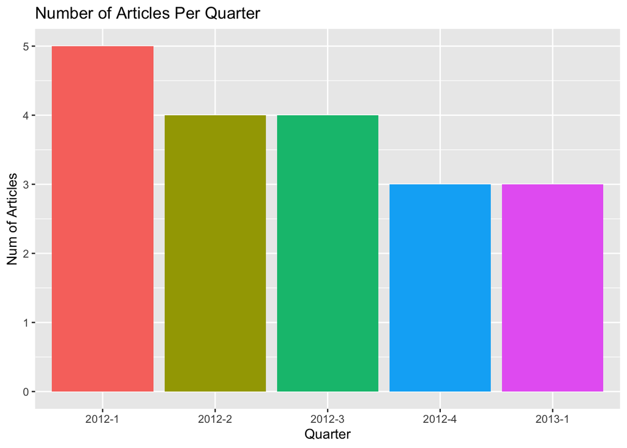

```r
# setting up the variables
x_axis <- seasonal_info$year_quarter
y_axis <- seasonal_info$article_count

# adorning the bar chart
seasonal_barChart <- ggplot(
  data = seasonal_info, aes(x = x_axis, y = y_axis)) +
  geom_bar(stat = "identity", aes(fill = year_quarter)) +
  labs(x = "Quarter", y = "Num of Articles") +
  ggtitle("Number of Articles Per Quarter") +
  guides(fill = FALSE)

print(seasonal_barChart)
```